# A2

# Setando o ambiente

```r
Sys.setlocale("LC_CTYPE", "pt_BR.UTF-8")
```

```
## [1] "pt_BR.UTF-8"
```

```r
if (!require("tidyverse")) install.packages("tidyverse")
if (!require("dplyr")) install.packages("dplyr")
if (!require("lubridate")) install.packages("lubridate")
if (!require("svglite")) install.packages("svglite")
library(tidyverse)
library(dplyr)
library(lubridate)
library(svglite)
custom_theme <- theme_bw() + theme(panel.grid = element_blank(),
                                   plot.title = element_text(hjust = 0.5, face = "bold"),
                                   plot.background = element_rect(fill = "#F1F4ED"),
                                   panel.background = element_rect(fill = "#F1F4ED"),
                                   panel.border = element_blank())
theme_set(custom_theme)
```

# The Office Database

The Office é uma série de televisão que estreou em 2005 nos EUA. É uma série no estilo de um documentário, no entanto, devido as situações irônicas e adversas que as personagens se encontram na série, a série tem um caráter de humor peculiar. O protagonista da série é Michael Scott, o qual é gerente regional de uma empresa de papel chamada Dunder Mifflin, e a maior parte do documentário relata o cotidiano nesse escritório e por isso a série se chama The Office. The office é uma das minhas séries favoritas, e procurando bases de dados pelo kaggle, encontrei uma base de dados sobre The Office e vi a oportunidade de realizar uma visualização com algo que me chamava atenção.

# 1. Parte A

## Explorando a base da dados

Antes de formular hipoteses sobre quais perguntas gostaria de responder, acho importante explorar a base de dados para assim saber com quais tipos de dados estamos lidando.

```r
theofficedf <- read.csv("the_office_series.csv", sep = ";")
```

```r
colnames(theofficedf)
```

```
##  [1] "Column1"      "Season"       "Episodes"     "EpisodeTitle" "Ratings"
##  [6] "Votes"        "Viewership"   "Duration"     "Date"         "GuestStars"
## [11] "Director"
```

## Formulando Hipoteses

A partir dessa prévia análise sobre a base de dados, podemos realizar já algumas perguntas a qual poderão ser respondidados com a base de dados: - Qual temporada teve mais telespectadores no total? - Qual temporada teve mais telespectadores por episódio? - Como foram as notas do IMDB por episódio? - Os episódios com “GuestStars” tem mais visualizações? - Qual diretor tem mais visualizações?

De modo a responder essas perguntas, organizaremos nossa base de dados de modo a ficar mais fácil possível a nossa representação.

# 2. Parte B - Análise Exploratória dos Dados

## Organização da base de dados

Algo que nos ajudará muito, será transformar as datas as quais utilizamos em nossa nossa base de dados, além de transformar em os dados da coluna episódios e temporadas em dados categóricos, pois assim, será mais fácil de futuramente trabalhar com ele.

```r
theofficedf$Date <- format(dmy(theofficedf$Date), "%d/%m/%Y")
theofficedf$Episodes <- factor(theofficedf$Episodes, levels = unique(theofficedf$Episodes))
theofficedf$Season <- factor(theofficedf$Season, levels = unique(theofficedf$Season))
```

## Primeiros gráficos

Vamos começar plotando alguns gráficos simples, tais como agrupar os dados por temporada, além de extrair a média de visualizações por temporada.

```r
por_temp <- theofficedf %>%
  group_by(Season) %>% summarise(Visualizacoes = sum(Viewership), media= mean(Viewership))
por_temp
```

```
## # A tibble: 9 × 3
##   Season Visualizacoes media
##   <fct>          <dbl> <dbl>
## 1 1               38.2  6.37
## 2 2              180.   8.17
## 3 3              195.   8.49
## 4 4              120.   8.55
## 5 5              228.   8.76
## 6 6              202.   7.77
## 7 7              175.   7.31
## 8 8              129.   5.39
## 9 9               95.2  4.14
```

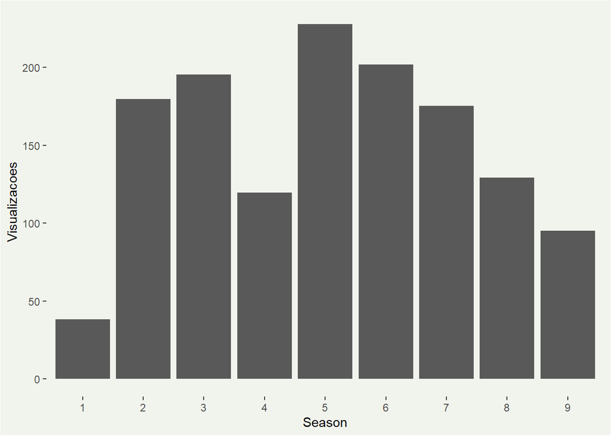

```r
graf_visu_por_temp <- ggplot(por_temp, aes(x = Season, y = Visualizacoes)) + geom_col()
graf_visu_por_temp
```

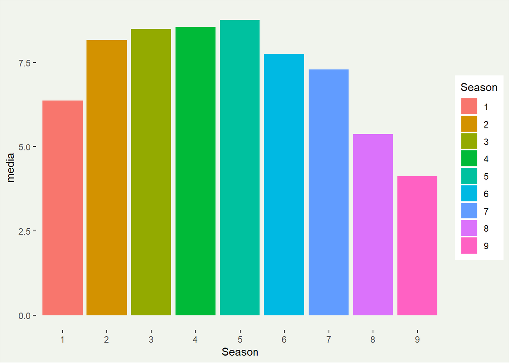

```r
graf_media_visu_por_temp <- ggplot(por_temp, aes(x = Season, y = media, fill = Season)) + geom_col()
graf_media_visu_por_temp
```

Vamos também analisar como foi a distribuição de visualizações em algumas temporadas:

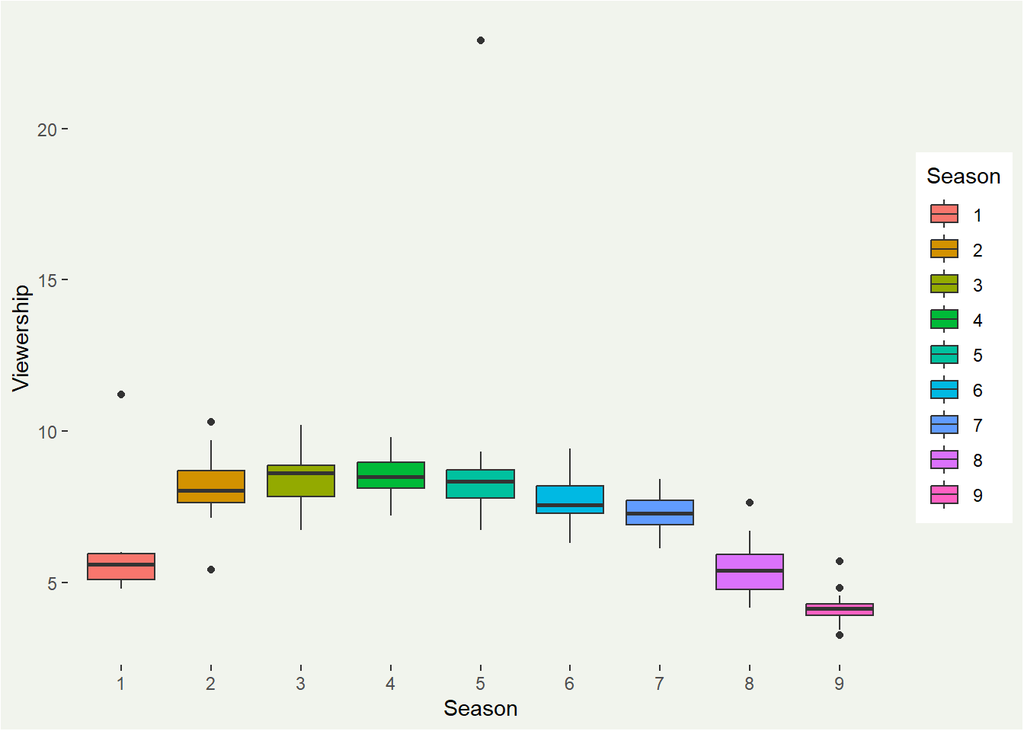

```r
theofficedf$Season <- as.character(theofficedf$Season)
graf_visu_por_ep <- ggplot(theofficedf, aes(x = Season, y = Viewership, fill = Season)) + geom_boxplot()
graf_visu_por_ep
```

### Trabalhando com os diretores

Vamos analisar quais diretores foram melhores avaliados, tanto em relação a média do público, mas também em relação a crítica do IMDB. Primeiramente, vamos separar nossa “base de dados”

```r
por_dir <- theofficedf %>%
  group_by(Director) %>%
  summarise(Visualizacoes = sum(Viewership), numero = n()) %>%
  arrange(desc(Visualizacoes)) %>%
  head(9) %>%
  arrange(desc(Visualizacoes)) %>%
  mutate(Director = reorder(Director, -Visualizacoes, FUN = max))
por_dir$media <- por_dir$Visualizacoes/por_dir$numero
por_dir <- arrange(por_dir, desc(media))
por_dir
```

```
## # A tibble: 9 × 4
##   Director          Visualizacoes numero media
##   <fct>                     <dbl>  <int> <dbl>
## 1 Jeffrey Blitz              96.9     11  8.81
## 2 Paul Feig                 127.      15  8.45
## 3 Greg Daniels              104.      13  8.01
## 4 Ken Kwapis                103.      13  7.91
## 5 Ken Whittingham            61.8      8  7.72
## 6 Randall Einhorn           114.      15  7.62
## 7 Paul Lieberstein           50.5      7  7.22
## 8 Charles McDougall          57.1      8  7.14
## 9 David Rogers               54.3      9  6.03
```

Com ela separada, basta plotarmos o gráfico

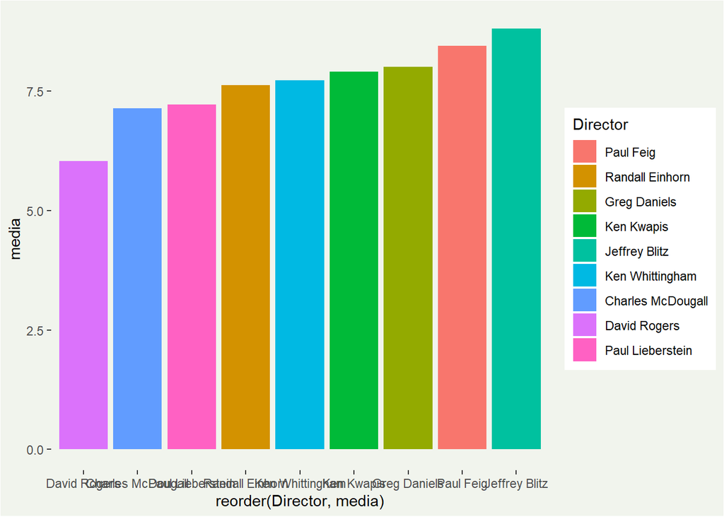

```r
graf_dire_por_ep <- ggplot(por_dir, aes(x = reorder(Director, media), y = media, fill = Director)) + geom_col()

graf_dire_por_ep
```

Já pela média do IMDB, precisaremos “separar” nossa base de dados novamente.

```r
por_imdb <- theofficedf %>%
  group_by(Director) %>%
  summarise(quant_ep = n(), media_imdb = mean(Ratings)) %>%
  filter(quant_ep > 4) %>%
  arrange(desc(media_imdb)) %>%
  head(10) %>%
  mutate(Director = reorder(Director, -media_imdb, FUN = max))
por_imdb <- por_imdb[-7, ]

por_imdb
```

```
## # A tibble: 9 × 3
##   Director          quant_ep media_imdb
##   <fct>                <int>      <dbl>
## 1 Paul Feig               15       8.75
## 2 Ken Kwapis              13       8.61
## 3 Greg Daniels            13       8.45
## 4 Charles McDougall        8       8.38
## 5 Jeffrey Blitz           11       8.31
## 6 Ken Whittingham          8       8.26
## 7 Paul Lieberstein         7       8.14
## 8 Randall Einhorn         15       8.11
## 9 B.J. Novak               5       7.92
```

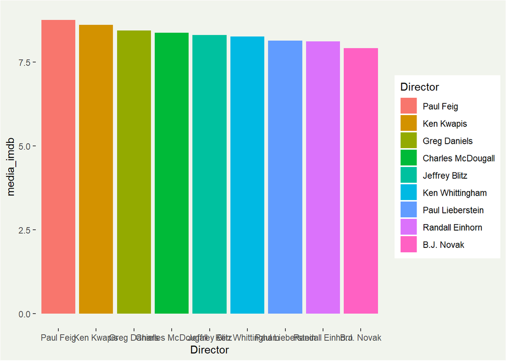

```r
graf_por_IMDB <- ggplot(por_imdb, aes(x=Director, y=media_imdb, fill = Director)) + geom_col()
graf_por_IMDB
```

### qual a influência de guest stars? Eles produzem outliers?

Vamos agora analisar qual a influência de personagens convidados. Vamos criar uma nova coluna que atribui 0 se o episódio não teve nenhum convidado, e atribui nota 1 se teve algum convidado.

```r
theofficedf$famosos <- ifelse(theofficedf$GuestStars == "", 0, 1)
theofficedf$famosos
```

```
##   [1] 0 0 0 0 0 1 0 0 1 1 0 0 1 0 1 0 1 0 0 0 0 1 0 0 0 0 0 0 0 1 0 0 0 0 0 0 0
##  [38] 0 0 0 0 0 0 0 0 0 0 0 0 0 0 0 0 1 0 0 0 0 0 0 0 0 0 0 0 0 1 0 0 0 0 0 0 0
##  [75] 0 0 0 1 0 0 0 0 1 0 0 0 0 0 0 0 0 0 0 0 0 0 1 0 0 0 0 0 0 0 0 1 0 0 1 0 0
## [112] 0 0 0 0 0 0 1 0 0 0 1 0 0 0 0 0 0 0 1 1 0 0 0 0 1 0 0 0 0 0 0 0 0 1 0 0 0
## [149] 0 1 0 0 0 0 0 0 0 0 0 0 0 0 0 1 0 0 0 0 0 1 1 0 0 0 1 0 0 0 0 0 0 0 1 0 0
## [186] 1 0 1
```

Agora vamos plotar a quantidade de visualizações em relação ao número do episódio, atribuindo cores e formatos diferentes para os pontos, de acordo com a coluna famosos.

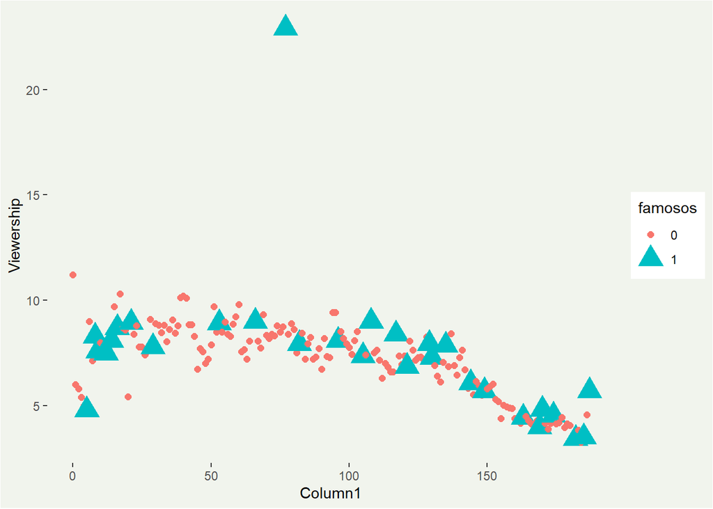

```r
theofficedf$famosos <- factor(theofficedf$famosos, levels = unique(theofficedf$famosos))

graf_disp_visu <- ggplot(theofficedf, aes(x = Column1, y = Viewership, color = famosos)) + geom_point(aes(shape = famosos, size = famosos))
graf_disp_visu
```

Por fim, vamos realizar um heatmap, no qual x é o episódio da série, e y a temporada relativa da série.

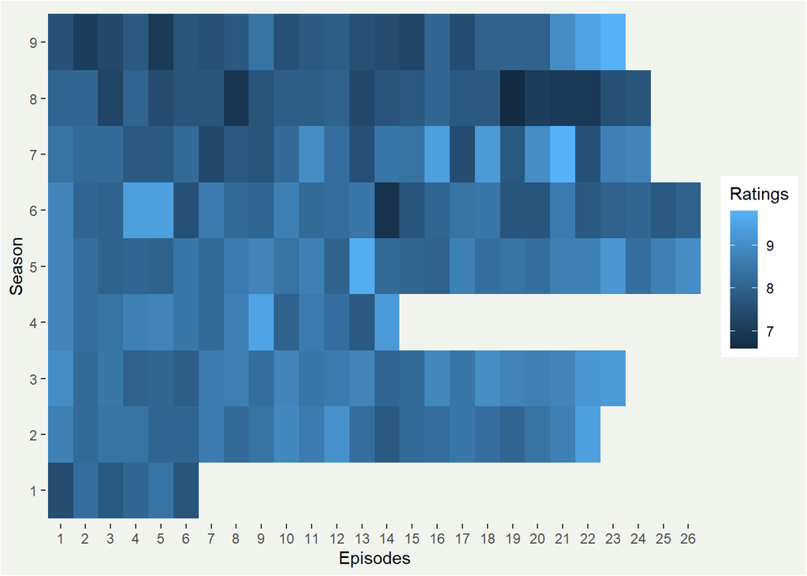

```r
heatmap <- ggplot(theofficedf, aes(x = Episodes, y=Season, fill=Ratings)) + geom_bin2d()
heatmap
```

# 3. Parte C - Visão editorial

## Definição do público alvo

Como essa análise será apresentada para a minha turma, à priori, meu público alvo são jovens na feixa etária de 16-20 anos, os quais já possuem um certo conhecimento para a leitura de gráficos. Desse modo, me utilizarei de alguns gráficos um pouco menos comuns a população geral, os quais seriam boxplots e heatmaps.

## Definição das cores

Minha ideia é ambientar o leitor para a estética da série, uma série de certa forma mais antiga. Assim, usarei as cores pasteis, as quais predominam por toda a série. Procurando por paletas de cores da série, encontrei uma imagem que tinha uma paeta de cores pastel que me lembrava a série. decidi usa-la.

```r
cores <- c("#F1F4ED", "#FFAB3B", "#425573", "#5C76A9", "#93BFE4", "#4CD2ED", "#9B6A4C", "#516D5B", "#BC3F47", "#2BA5A8")
```

## Qualidade Expressiva da peça

Como as cores escolhidas tem um carater mais pastel, o meu modo de comunicação vai ser neutro.

## Recursos de exibição

Minha ideia é produzir os gráficos no R, e utilizar o canvas para juntar todos os gráficos e apresenta-los.

## Representação do dado

Nessa parte, irei refinar todos os gráficos apresentados na parte de análise exploratória.

## Gráficos com as visualizações por temporada

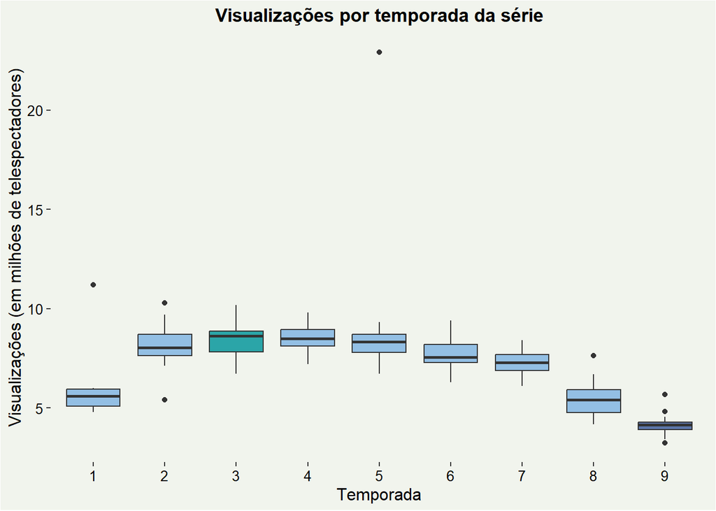

```r
graf_boxplot <- graf_visu_por_ep +
  scale_fill_manual(values = c("#93BFE4", "#93BFE4", "#2BA5A8" , "#93BFE4", "#93BFE4", "#93BFE4", "#93BFE4", "#93BFE4",  "#5C76A9")) +
  guides(fill = "none") +
  labs(x = "Temporada",
       y = "Visualizações (em milhões de telespectadores)",
       title = "Visualizações por temporada da série")+
  theme(axis.text = element_text(color = "black", size = 10),
        axis.title = element_text(color = "black", size = 12))
graf_boxplot
```

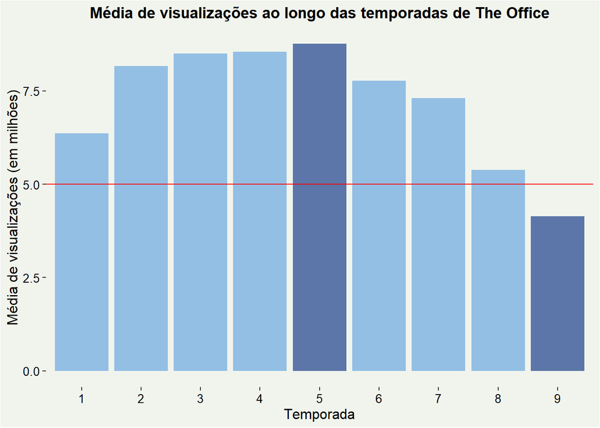

```r
graf_colunas_visu <- graf_media_visu_por_temp +
  labs(x = "Temporada",
       y = "Média de visualizações (em milhões)",
       title = "Média de visualizações ao longo das temporadas de The Office") +
  geom_hline(yintercept = 5, color = "red") +
  scale_fill_manual(values = c("#93BFE4", "#93BFE4", "#93BFE4" , "#93BFE4", "#5C76A9", "#93BFE4", "#93BFE4", "#93BFE4",  "#5C76A9")) +
  guides(fill = "none") +
  theme(axis.text = element_text(color = "black", size = 10),
        axis.title = element_text(color = "black", size = 12))
graf_colunas_visu
```